# scRNA-seq import and QC of placental villous tissue

# Single-cell RNA-seq analysis of KC and TNL Pique-Regi placental villous tissue samples

### Important References

Minimal QC recommended: Current best practices in single‐cell RNA‐seq analysis: a tutorial Orchestrating Single-cell Analysis ### Compiling Issues This document had trouble compiling via knitr and pandoc. The following thread fixed the issue (https://github.com/rstudio/rstudio/issues/3661).

## Load Data

```r
seu <- readRDS(paste0(data_dir, "kc_pr_qc_merged_2020-12-15.rda"))
```

## QC Plots

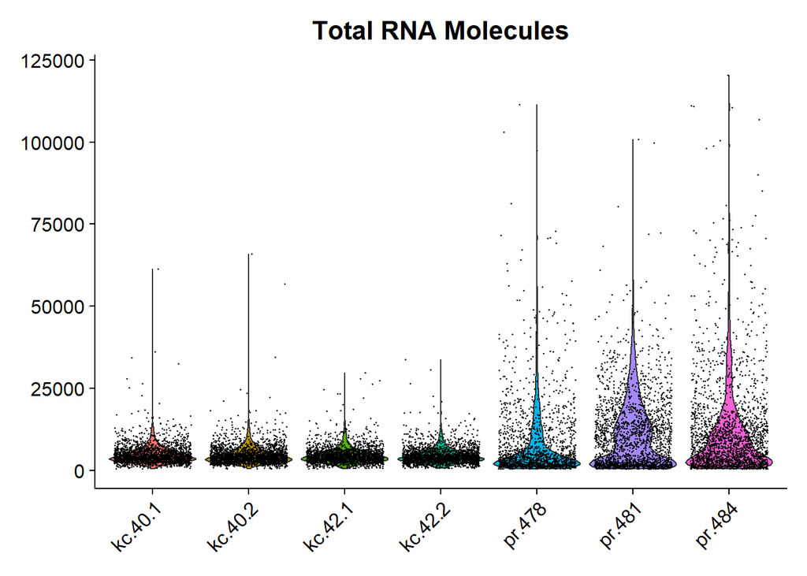

```r
VlnPlot(object=seu, features='nCount_RNA', pt.size=0.15, group.by = 'orig.ident') + NoLegend() + ggtitle("Total RNA Molecules") + theme(axis.title.x = element_blank())
```

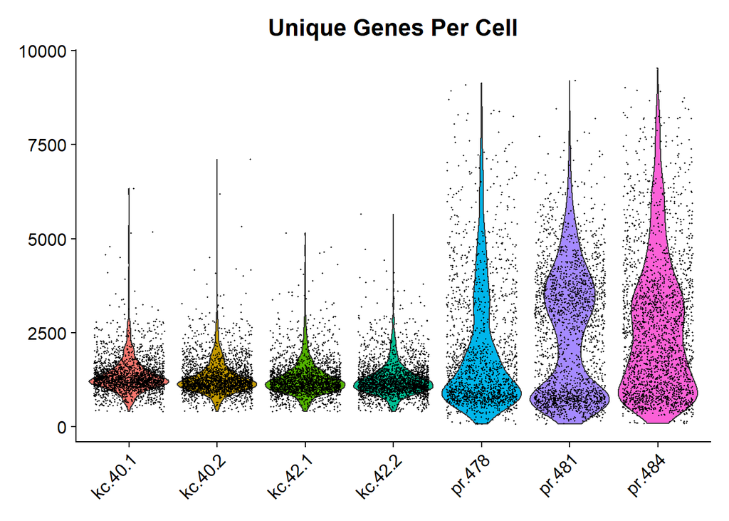

```r
VlnPlot(object=seu, features='nFeature_RNA',pt.size=0.15, group.by = 'orig.ident') + NoLegend() + ggtitle("Unique Genes Per Cell") + theme(axis.title.x = element_blank())
```

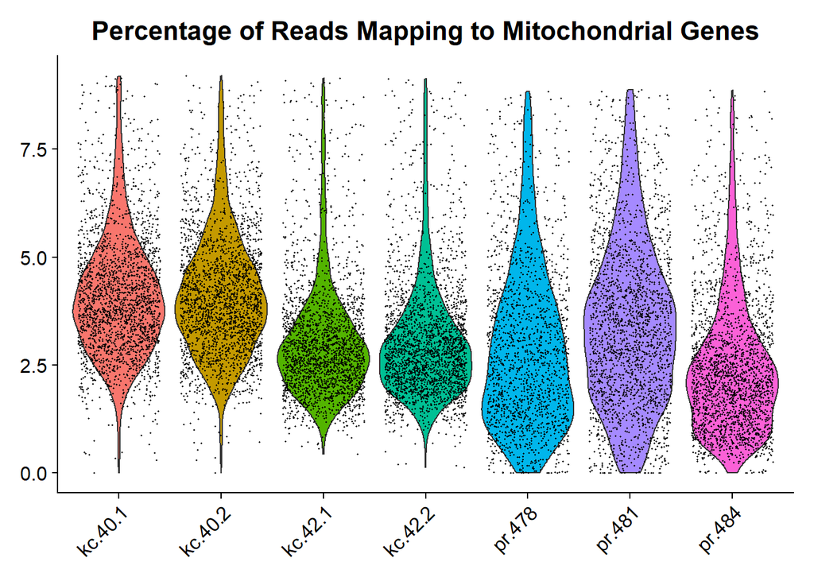

```r
VlnPlot(object=seu, features='subsets_Mito_percent',pt.size=0.15, group.by = 'orig.ident') + NoLegend() + ggtitle("Percentage of Reads Mapping to Mitochondrial Genes") + theme(axis.title.x = element_blank())
```

## QC Tabulation

```r
# Total number of genes
#genes <- AverageExpression(object = All, features = 'nFeature_RNA', verbose = T)
#dim(genes$RNA)[1]
```

## Pre-processing for Clustering

After filtering of unwanted cells and QC assessment, the first step of clustering is to normalize the data. By default (used here), Seurat globally normalizes feature expression for each cell by total expression, multiplies by a scale factor of 10,000, and log-transforms the result.

Find variable features identifies variable genes in a feature selection step for downstream analysis. Default options are the “vst” selection method, and top 2000 features returned. The variance stabilizing transformation (VST) first fits a line to the relationship of log(variance) and log(mean) using local polynomial regression (“loess”). The second step standardizes the feature values using the observed mean and expected variance (given by the fitted line). Feature variance is then calculated on the standardized values after clipping to a maximum (clip.max parameter). “loess.span” is the span paramter used when fitting the variance-mean relationship. After standardization, values larger than “clip.max” will be set to “clip.max”; by default, is ‘auto’ which sets “clip.max” to the square root of the number of cells.

```r
# Should normalize and find variable features in each dataset separately
seu <- NormalizeData(object = seu, normalization.method = "LogNormalize", scale.factor = 10000)
seu <- FindVariableFeatures(object = seu)
```

```r
all.genes <- rownames(seu)
seu <- ScaleData(seu, features = all.genes)
seu <- RunPCA(seu, features = VariableFeatures(object = seu))
```

```
## PC_ 1
## Positive:  PEG10, XAGE3, KRT18, PAGE4, SPINT1, DUSP9, TINAGL1, VGLL1, KRT7, XAGE2
##     TCEAL9, ISYNA1, KRT8, FBN2, EFEMP1, PHLDA2, FXYD3, TUSC3, PERP, EGFR
##     CD24, ITIH5, SMAGP, BEX3, SPINT2, ISM2, IFI6, CLDN4, MORC4, BCAM
## Negative:  CD74, VIM, HLA-DRA, HLA-DRB1, FTL, FTH1, HLA-DPB1, HLA-DPA1, SOD2, TIMP1
##     CXCL8, GPR183, LST1, LYZ, PLAUR, S100A8, BCL2A1, IL1B, ISG15, CCL5
##     IL32, HLA-DQA1, CCL4, RGS1, CD83, FCN1, TRBC1, G0S2, CCL3, KLRB1
## PC_ 2
## Positive:  HMGA1, CD74, SLC25A5, HLA-DRA, HLA-DRB1, FTH1, SMS, ADGRG1, DNMT1, HLA-DPB1
##     HLA-DPA1, NFE2L3, H2AFZ, CD24, SLC13A4, MPP1, MT2A, SMAGP, IFI30, SLC27A2
##     C15orf48, PERP, LRATD1, SIGLEC6, CDO1, FOXO4, CSF2RA, EGFR, S100A9, MIR205HG
## Negative:  EGFL6, DCN, LUM, COL3A1, DLK1, COL6A1, SPARC, COL1A1, HGF, TCF21
##     RARRES2, CXCL14, CTHRC1, IGFBP3, APOD, MEG3, SRPX, COL6A2, OLFML3, PDPN
##     MMP2, ENPP1, PTGDS, CADM3, WNT2, COL1A2, MFAP4, SERPINE2, HSD17B2, PLAC9
## PC_ 3
## Positive:  HMGB1, SERPINF1, LDHB, MEST, NREP, LUM, PHACTR2, TYMS, DCN, PTGDS
##     DLK1, EGFL6, CDK1, CXCL14, CCNA2, TCF21, APOD, SLC40A1, RARRES2, COL14A1
##     EFEMP1, PBK, CCNB2, HGF, TOP2A, PDPN, DEPDC1, PCLAF, COL3A1, COL1A1
## Negative:  PAPPA, PAPPA2, HLA-G, LVRN, EBI3, CORO6, COL17A1, AOC1, ASCL2, NOTUM
##     LINC02246, CST6, MCAM, SLCO2A1, FSTL3, QSOX1, DIO2, FN1, PLPP2, SERPINE1
##     TNFSF10, AC211433.1, PYCR1, MYCNUT, HTRA4, CLDN19, BGN, EGFR-AS1, PRG2, TIMP2
## PC_ 4
## Positive:  IL32, TRBC1, KLRB1, CCL5, C12orf75, GZMA, TRAC, PRF1, IL2RB, GZMH
##     GZMB, HOPX, FGFBP2, GNLY, CD8A, KLRF1, B3GNT7, LAIR2, CD79A, SPON2
##     TRGC2, RGS1, CLIC3, KLRC1, LINC01871, CD8B, IGHM, PAPPA, GPR171, TRDC
## Negative:  LYZ, PLAUR, SERPINA1, LST1, S100A9, FCN1, CD68, IFI30, MAFB, SOD2
##     IL1B, S100A8, C5AR1, BCL2A1, G0S2, CXCL2, CXCL8, S100A12, TREM1, MS4A6A
##     NLRP3, TIMP1, AQP9, FTL, SMIM25, CD14, KYNU, AC020656.1, CTSB, LGALS2
## PC_ 5
## Positive:  CDK1, CCNA2, MKI67, TOP2A, PBK, BIRC5, UBE2C, AURKB, DEPDC1, NUSAP1
##     TYMS, CENPF, HMMR, PCLAF, SPC25, ANLN, PLK1, TK1, GTSE1, CDCA3
##     CDC20, CENPA, MAD2L1, NUF2, TPX2, PRC1, CDKN3, KIF23, DLGAP5, CCNB2
## Negative:  HSD17B1, INSL4, GSTA3, EPS8L1, SLC52A1, TMEM40, CYP19A1, P2RY6, PRKCZ, LCMT1-AS2
##     TMEM150A, AC110619.1, SLC22A11, ERVW-1, S100P, MUC15, TACC2, AC005532.1, SLC26A2, SIAH1
##     SLC13A4, ESRRG, SLC40A1, GSTA4, SEMA6A, FXYD3, LINC01990, RAI14, RHOBTB1, SVEP1
```

Elbow plot to identify the dimensionality of the dataset. Seurat errs on the side of selecting more rather than fewer PCs because too few PCs can significantly affect the result.

ElbowPlot() plots the standard deviations (or approximate singular values if running PCAFast) of the principle components for easy identification of an elbow in the graph. This elbow often corresponds well with the significant dims.

GSEA could be conducted on the PCs to see if they identify cell types or a group of similar cell types.

50 looks like more than enough to capture the variability in the dataset.

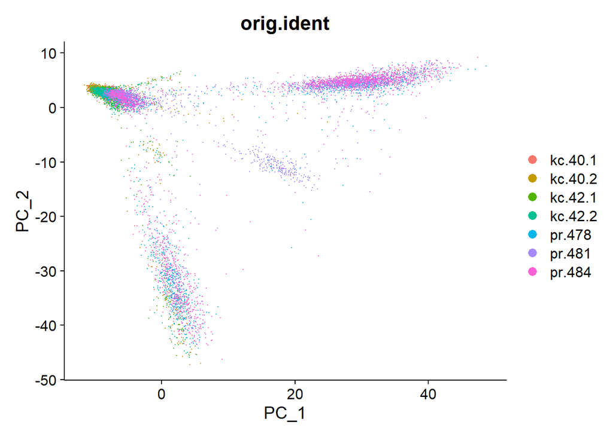

```r
DimPlot(seu, reduction = "pca", group.by = 'orig.ident')
```

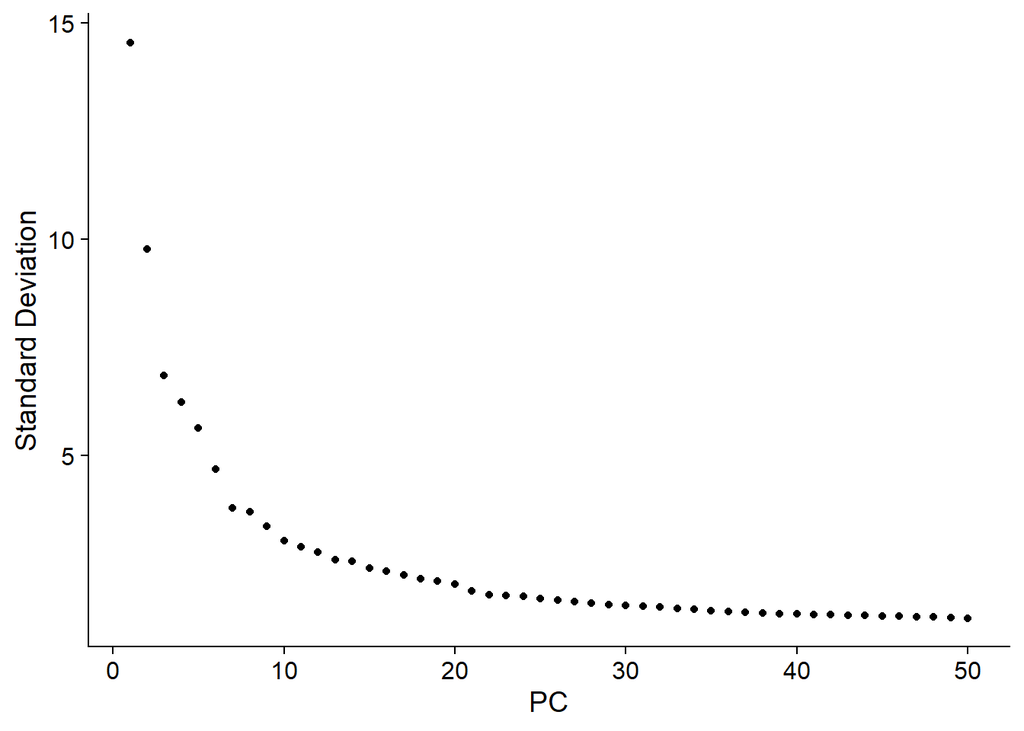

```r
ElbowPlot(object = seu, ndims = 100)
```

## Uncorrected Clustering, t-SNE, UMAP

Next, we use a non-linear dimensional reduction technique to embed the first 50 PCs of the dataset into two dimensions for visualization and exploration. Seurat recommends using the same number of PCs for t-SNE and neighbor-graph. Each point represents a single cell’s transcriptome. Cells with similar gene expression profiles are plotted closer together. To identify communities (cell types in this biological context), Seurat creates a shared nearest neighbor graph and creates communities that optimize “modularity”, the density of links within communities compared to links between communities.

```r
# Don't want to re-run
seu <- RunTSNE(seu, dims.use = 1:50, do.fast = T, dim.embed = 2)
seu <- FindNeighbors(object=seu, dims=1:50, reduction='pca')
seu <- RunUMAP(object = seu, dims = 1:50)
seu <- FindClusters(object = seu, resolution = 0.8) #default is 0.8; 0.2 looks stable in the kc dataset
```

```
## Modularity Optimizer version 1.3.0 by Ludo Waltman and Nees Jan van Eck
##
## Number of nodes: 15955
## Number of edges: 718178
##
## Running Louvain algorithm...
## Maximum modularity in 10 random starts: 0.9224
## Number of communities: 27
## Elapsed time: 1 seconds
```

```r
table(seu@meta.data$seurat_clusters)
```

```
##
##    0    1    2    3    4    5    6    7    8    9   10   11   12   13   14   15
## 1792 1682 1535 1342 1303 1129  863  769  636  586  581  578  521  474  382  250
##   16   17   18   19   20   21   22   23   24   25   26
##  241  236  200  158  155  136  121  120   70   55   40
```

```r
table(seu@meta.data$seurat_clusters,seu$orig.ident)
```

```
##
##      kc.40.1 kc.40.2 kc.42.1 kc.42.2 pr.478 pr.481 pr.484
##   0      513     488     371     415      3      1      1
##   1      258     314     492     508     41     53     16
##   2      496     468     275     276      8      8      4
##   3      289     305     348     351     27      7     15
##   4      369     396     247     277      8      3      3
##   5       56      47      61      65    386     12    502
##   6        2       0       0       0     12    844      5
##   7        0       0       0       0      5      1    763
##   8       96      95     200     209     19      6     11
##   9        1       3       2       0    306    242     32
##   10       6       3      29      33    115    118    277
##   11       0       1       0       0    119    171    287
##   12     131     142      51      69     34     14     80
##   13       1       2       2       1    348     66     54
##   14       0       1       4       3    110    220     44
##   15       0       0       0       0     11    234      5
##   16      18      25      87     105      3      1      2
##   17      11      21      87     111      1      3      2
##   18      32      31      54      73      2      6      2
##   19       0       0       0       0     21     31    106
##   20       1       0       0       0     69     32     53
##   21      17      14      22      24     30     20      9
##   22       5      22       3       2      6     83      0
##   23       1       2       0       3     30     18     66
##   24       6      11      22      15      1      8      7
##   25       0       0       4       1     26      9     15
##   26      11      17       5       7      0      0      0
```

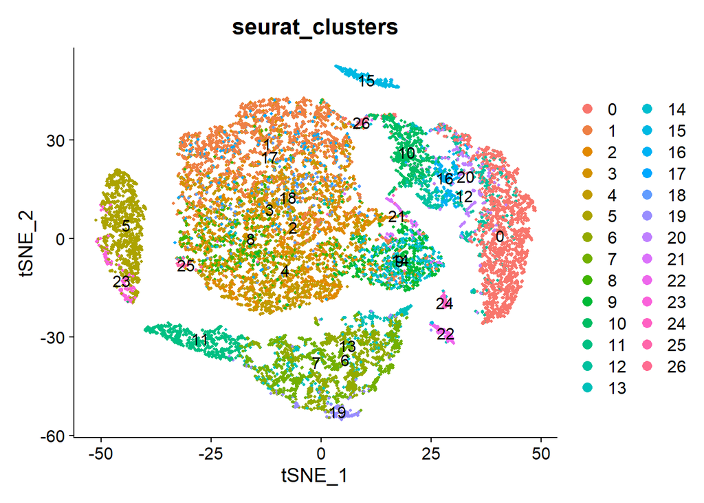

```r
# tSNE plot by sample cluster
DimPlot(object = seu,pt.size=0.7,reduction='tsne',group.by='seurat_clusters', label = T)
```

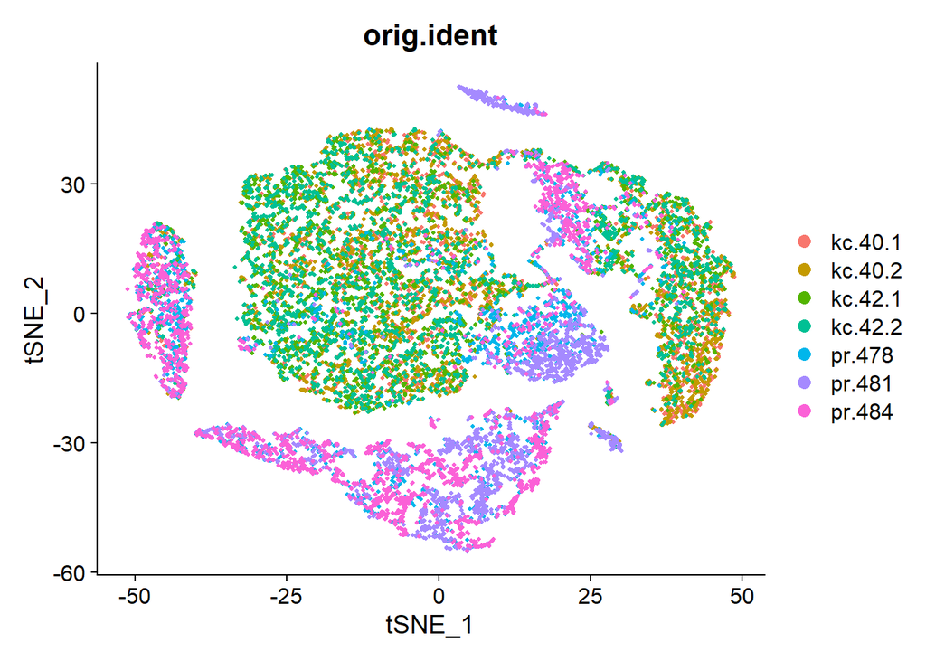

```r
DimPlot(object = seu,pt.size=0.7,reduction='tsne',group.by='orig.ident')
```

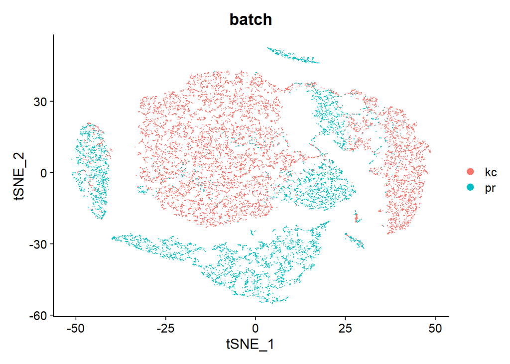

```r
DimPlot(object = seu,pt.size=0.01,reduction='tsne',group.by='batch')
```

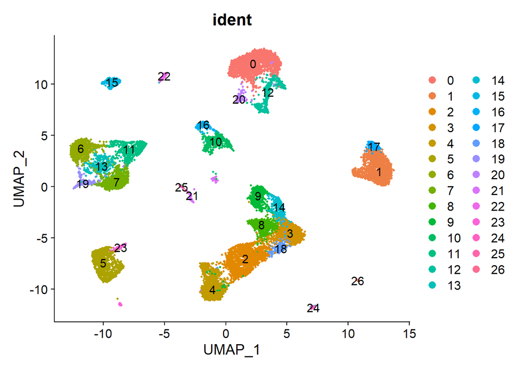

```r
# UMAP plot by sample cluster
DimPlot(object = seu,pt.size=0.7,reduction='umap',group.by='ident', label = T)
```

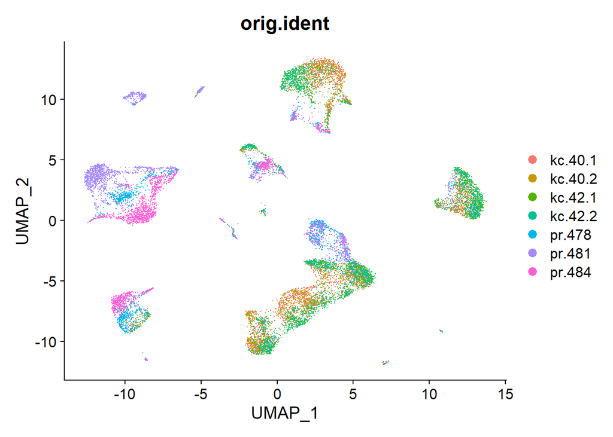

```r
DimPlot(object = seu,pt.size=0.01,reduction='umap',group.by='orig.ident')
```

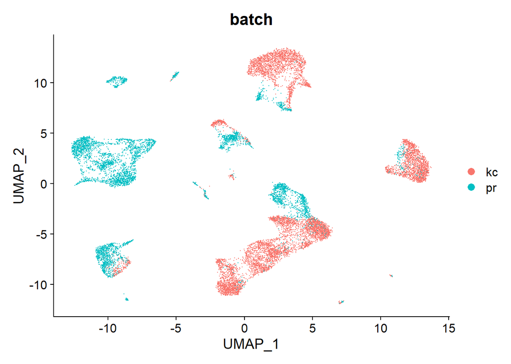

```r
DimPlot(object = seu,pt.size=0.01, reduction='umap',group.by='batch')
```

```r
#saveRDS(All,file='combined_uncorrected.rda')
```

## MNN Correction and Clustering

Re-running pipeline after MNN correction, batch correct for biological replicate

```r
# Mutual Nearest Neighbor Reduction
# RunFastMNN, splitting by biological replicate (i.e., KC40 vs. KC42 vs. each tnl sample)
seu <- RunFastMNN(object.list = SplitObject(seu, split.by = "biorep"))
```

```
## Computing 2000 integration features
```

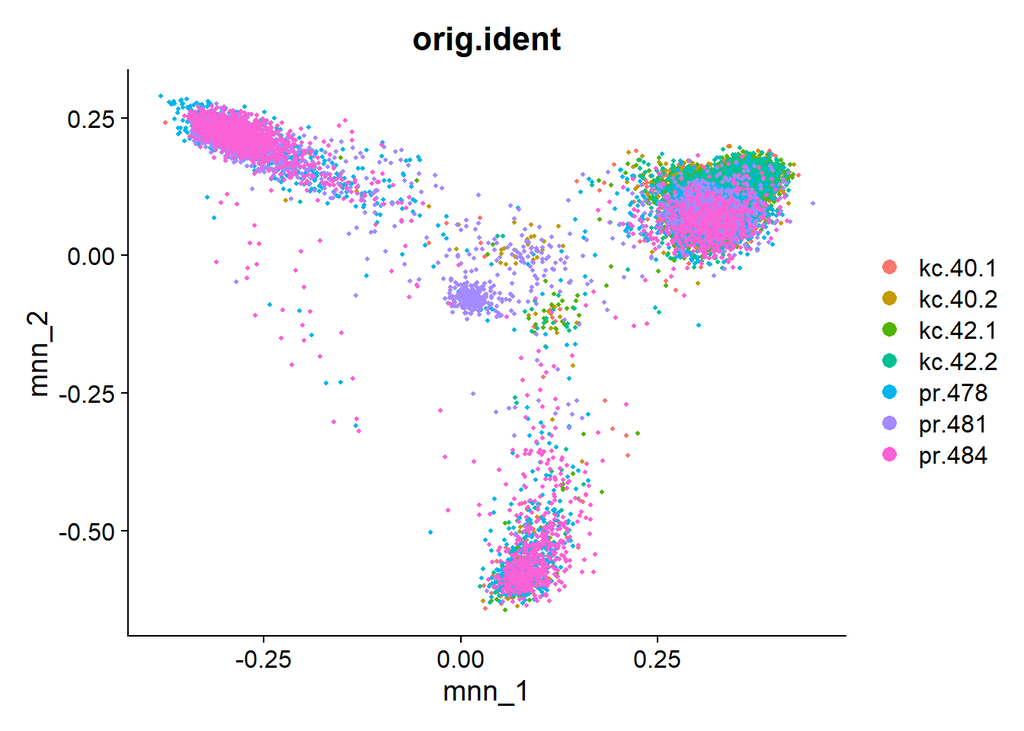

```r
DimPlot(object = seu,pt.size=0.7,reduction='mnn', group.by='orig.ident')
```

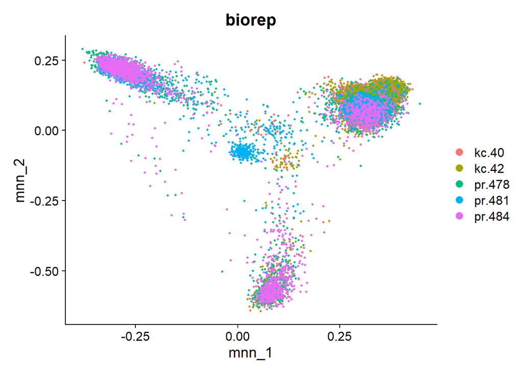

```r
DimPlot(object = seu,pt.size=0.7,reduction='mnn', group.by='biorep')
```

```r
# Re-run UMAP and cluster pipeline after MNN correction
seu <- RunUMAP(seu, reduction = "mnn", dims = 1:50)
seu <- FindNeighbors(seu, reduction = "mnn", dims = 1:50)
seu <- FindClusters(seu, resolution = 0.2)
```

```
## Modularity Optimizer version 1.3.0 by Ludo Waltman and Nees Jan van Eck
##
## Number of nodes: 15955
## Number of edges: 734295
##
## Running Louvain algorithm...
## Maximum modularity in 10 random starts: 0.9679
## Number of communities: 15
## Elapsed time: 1 seconds
```

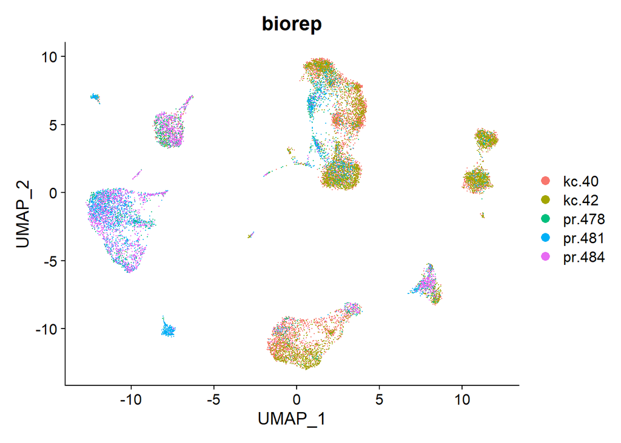

```r
# 'biorep' is metadata describing biological replicates
DimPlot(seu, group.by = 'biorep')
```

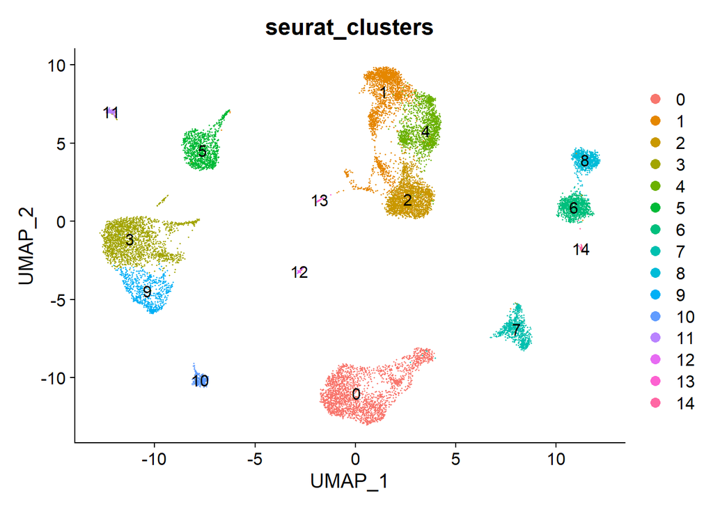

```r
# 'seurat_clusters' is metadata describing default clustering'
DimPlot(seu, group.by = 'seurat_clusters', label = T, pt.size = .25)
```

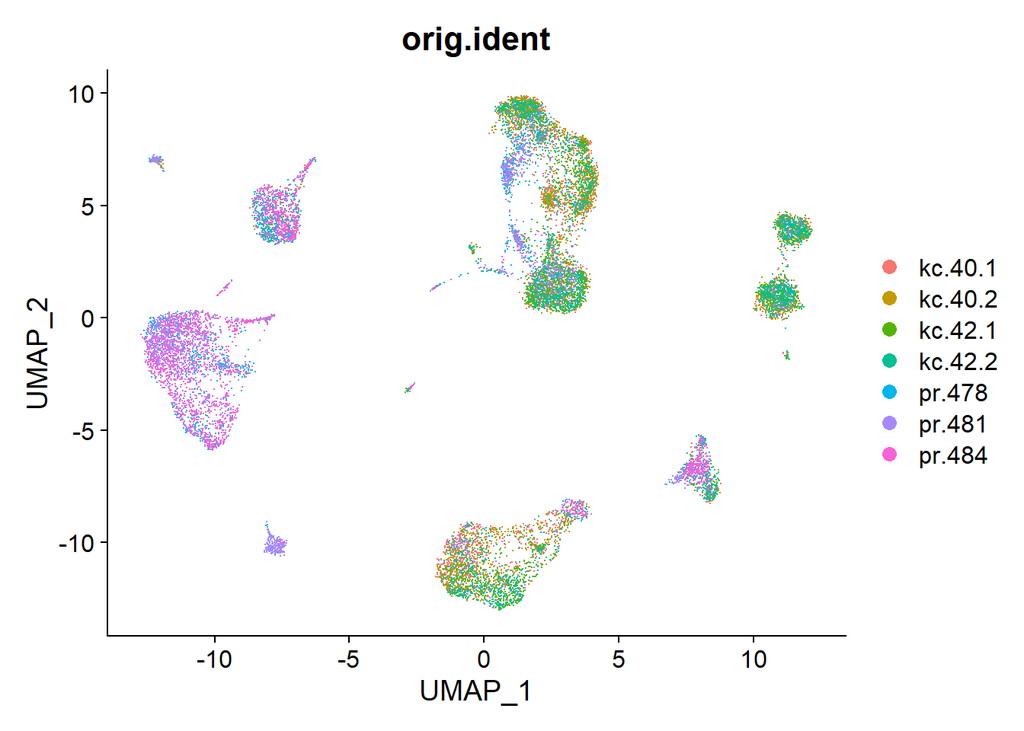

```r
# 'SampleName' describes KC40A (1A), KC40B (1B), KC42A (2A), KC42B (2B)
DimPlot(seu, group.by = 'orig.ident')
```

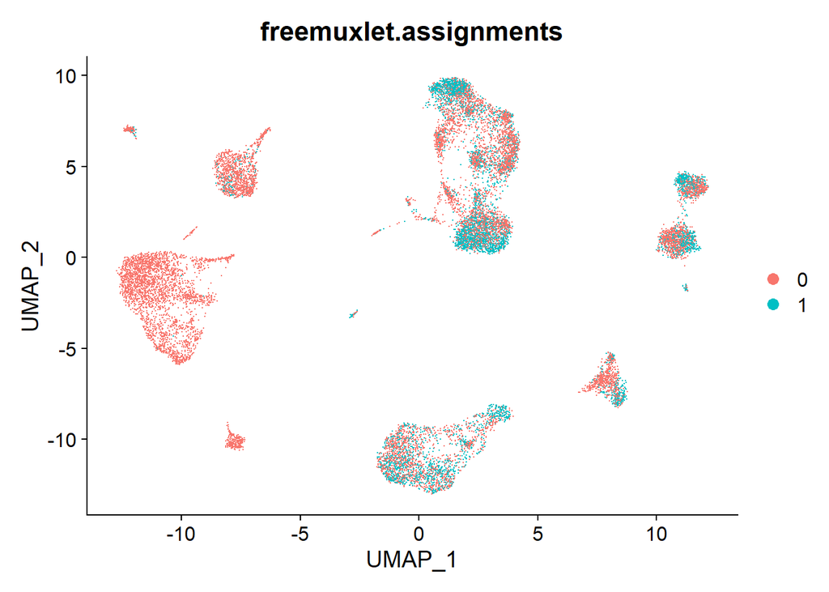

```r
DimPlot(seu, group.by = 'freemuxlet.assignments')
```

## Assigning maternal/fetal status and sex Plotting several sex-specific transcripts, it is clear that KC42, PR478, and PR484 are all male fetuses. Markers come from “Robust and tissue-independent gender-specific transcript biomarkers.”, published using peripheral blood as sample source (RPS4Y1, EIF1AY, DDX3Y, KDM5D and XIST; XIST being upregulated in females compared to males).

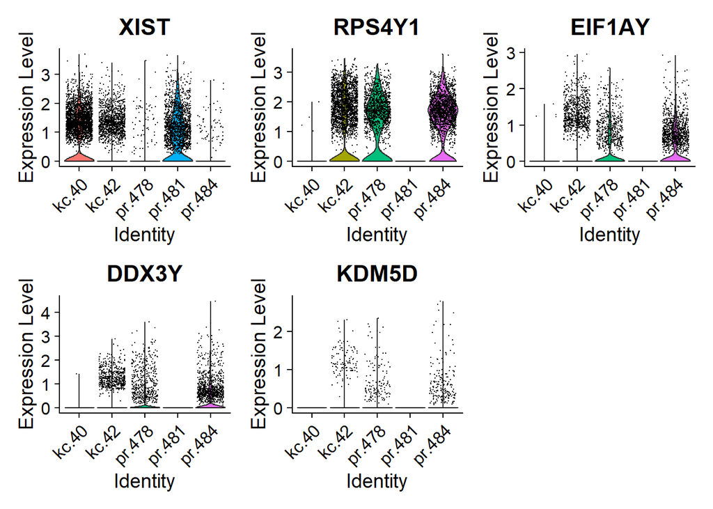

```r
VlnPlot(object= seu,
        features = c("XIST", "RPS4Y1", "EIF1AY", "DDX3Y", "KDM5D"),
        group.by = 'biorep')
```

Grouping by biological replicate and then splitting by freemux assignment (0/1), plotting the three most robustly expressed genes in the dataset, we clearly see that 0 (the more abundant of the two individuals) corresponds to the fetus in PR478 and PR484, and 1 corresponds to the fetus in KC42 (the less abundant of the two individuals). It can be inferred this pattern holds for PR481 and KC40, but will verify with placental gene expression below.

```
## The default behaviour of split.by has changed.
## Separate violin plots are now plotted side-by-side.
## To restore the old behaviour of a single split violin,
## set split.plot = TRUE.
##
## This message will be shown once per session.
```

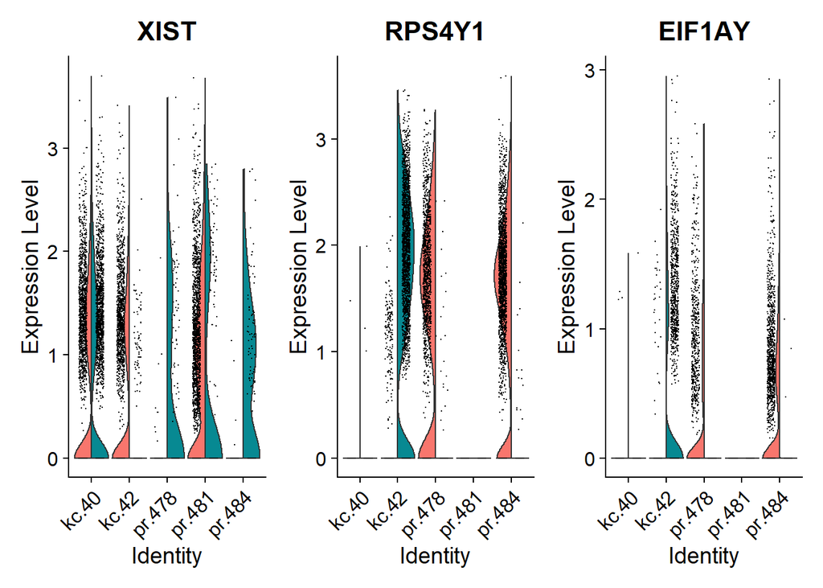

```r
VlnPlot(object= seu,
        features = c("XIST", "RPS4Y1", "EIF1AY"),
        group.by = 'biorep',
        split.by = 'freemuxlet.assignments',
        split.plot = T)
```

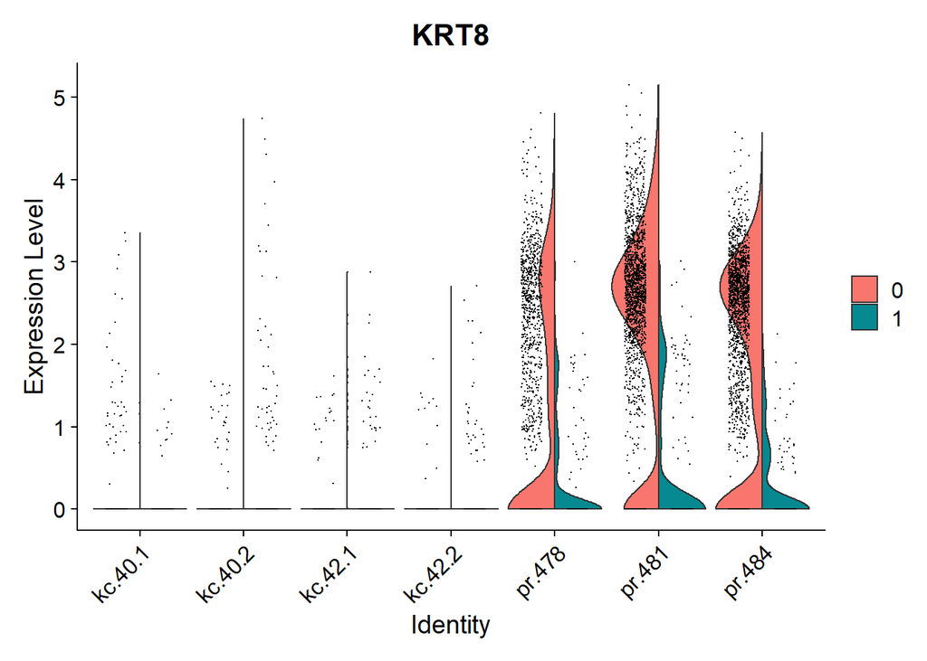

```r
VlnPlot(object= seu,
        features = c("KRT8"),
        group.by = 'orig.ident',
        split.by = 'freemuxlet.assignments',
        split.plot = T)
```

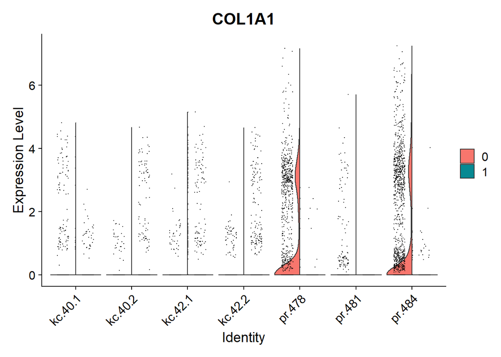

```r
VlnPlot(object= seu,
        features = c("COL1A1"),
        group.by = 'orig.ident',
        split.by = 'freemuxlet.assignments',
        split.plot = T)
```

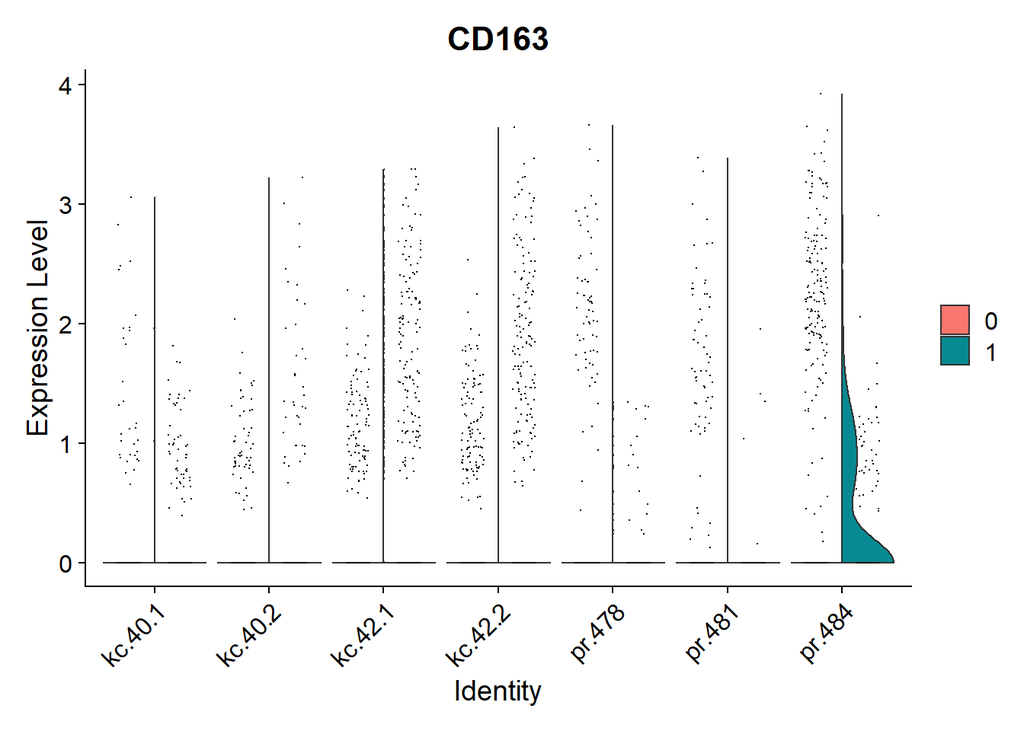

```r
VlnPlot(object= seu,
        features = c("CD163"),
        group.by = 'orig.ident',
        split.by = 'freemuxlet.assignments',
        split.plot = T)
```

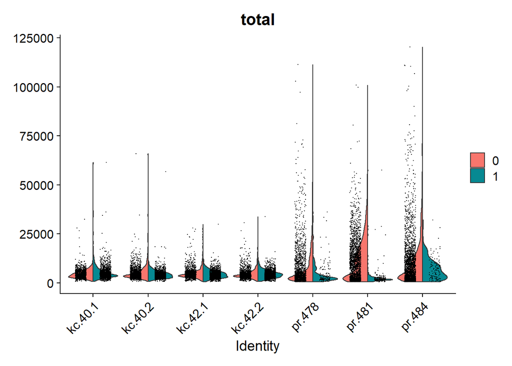

```r
VlnPlot(object= seu,
        features = c("total"),
        group.by = 'orig.ident',
        split.by = 'freemuxlet.assignments',
        split.plot = T)
```

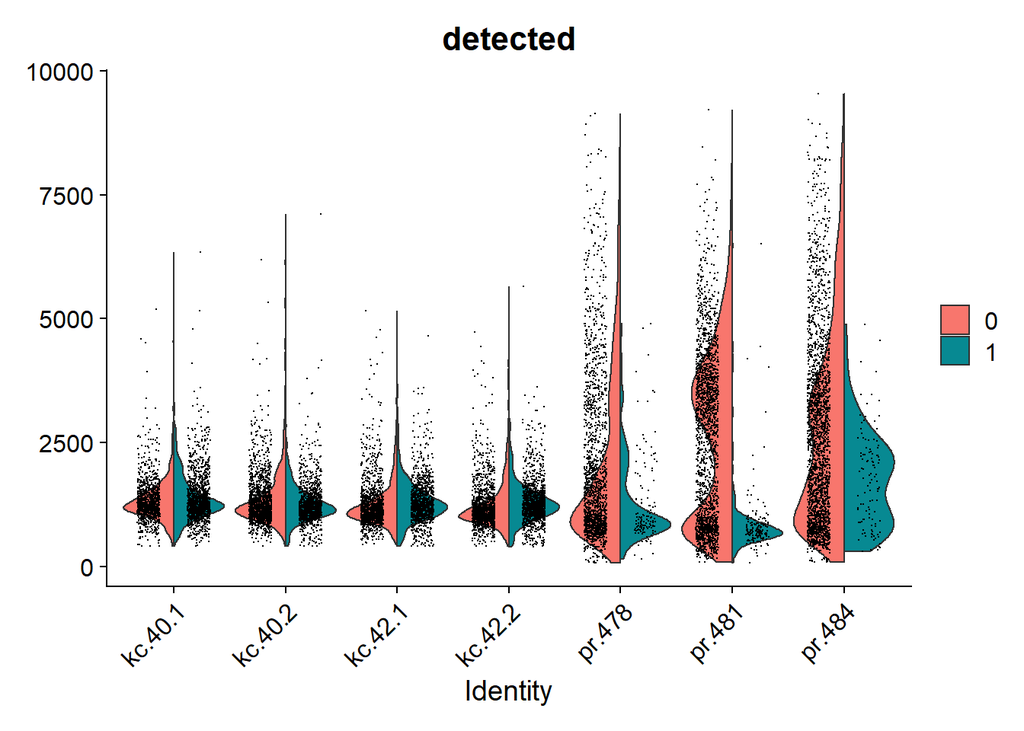

```r
VlnPlot(object= seu,
        features = c("detected"),
        group.by = 'orig.ident',
        split.by = 'freemuxlet.assignments',
        split.plot = T)
```

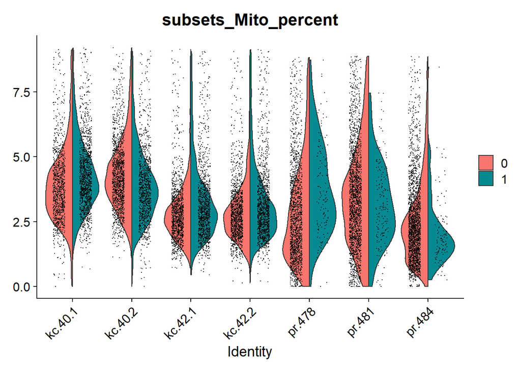

```r
VlnPlot(object= seu,
        features = c("subsets_Mito_percent"),
        group.by = 'orig.ident',
        split.by = 'freemuxlet.assignments',
        split.plot = T)
```

From above, KC42, freemux 1 is the fetus. It looks like in almost every KC sample except kc.40.1, freemux 1 is the fetus. Based on these findings, PR freemux 0 corresponds to fetus, KC freemux 0 corresponds to maternal except for KC40.1

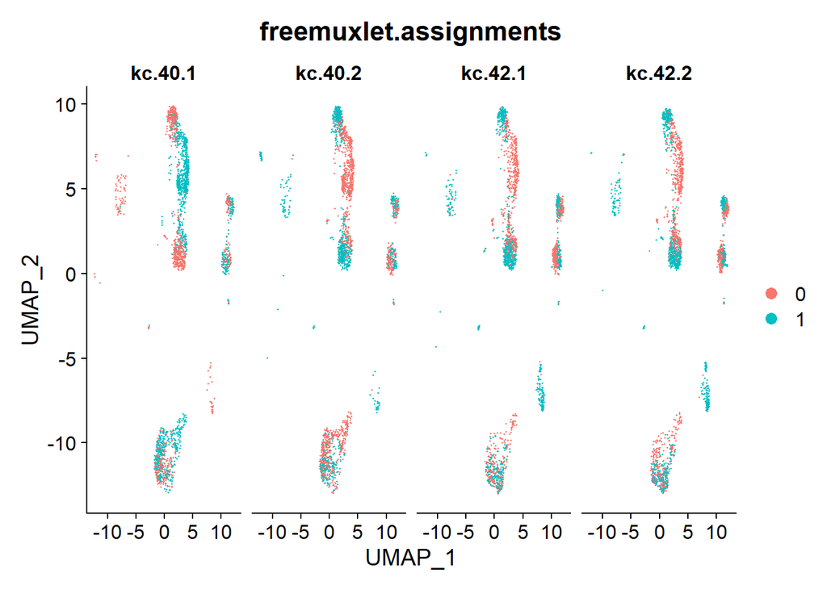

```r
batch <- SplitObject(seu, split.by = "batch")
kc <- batch$kc
pr <- batch$pr
rm(batch)
DimPlot(kc, group.by = 'freemuxlet.assignments', split.by = 'orig.ident', pt.size = .25)
```

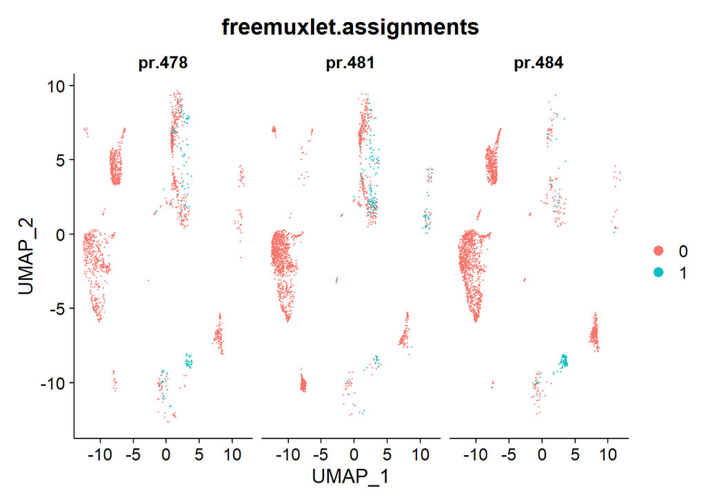

```r
DimPlot(pr, group.by = 'freemuxlet.assignments', split.by = 'orig.ident', pt.size = .25)
```